# L24 LAB 11 (MD)

AnaGSanjuanM

2023-02-22

Hecho con gusto por Carla Carolina Pérez Hernández (UAEH)

Visión clara del espacio-producto: CASO REAL_exportaciones hidalguenses

Objetivo: Estimar el Maximum Spanning Tree -Árbol de expansión máxima- (asegurar una visión clara del espacio-producto)

Red troncal: Estructura general de la red: vamos a poder ver redes complejas

Regla 1: mantener n-1 conexiones como máximo

Regla 2: Quitar las conexiones con el peso más bajo, nos vamos quedar con las del peso máximo (menos conexiones)

Regla 3: No crear nodos aislados

En este ejercicio vamos a:

1. Usar una matríz de datos que contiene el relacionamiento de las exportaciones hidalguenses
2. Graficar sus próximos adyacentes

————————LABORATORIO 11—————————————

—————Alumna: Ana Grisel Sanjuan Merida—————————–

Cómo crear una Visión clara del espacio-producto: árbol de expansión máxima (MST) Paquete: Balland, P.A. (2017) Economic Geography in R: Introduction to the EconGeo Package, Papers in Evolutionary Economic Geography, 17 (09): 1-75 Para instalar: https://www.paballand.com/install-r

1. Cargar la matriz de proximidades (Relatedness) “CASO ESPACIO-PRODUCTO DE EXPORTACIONES HIDALGUENSES”
2. Estimar el árbol de expansión máixma (MST)
3. Graficar

Cargar paquete

```r
library(EconGeo)
```

Importar matriz “relatednessbinario.csv”. Ubicar archivo.

```r
file.choose()
```

```
## [1] "C:\\Users\\Lenovo\\Documents\\GitHub\\LAB-11\\L11 Input\\relatednessbinario.csv"
```

Abre ventana y selecciono el archivo. Copio la ubicación desde la consola (cuadrante inferior) desde donde inician las comillas hasta donde terminan.

Se copia en este comando. Se genera mariz.

```r
M = as.matrix(
  read.csv("C:\\Users\\Lenovo\\Documents\\GitHub\\LAB-11\\L11 Input\\relatednessbinario.csv" ,
           sep = ",",
           header = T,
           row.names = 1))
```

En en panel de objetos (Environmet) se muestra el objeto M que es la matriz compleja

Para visualizar diez datos de la matriz. Son 429 renglones y 429 columnas. Es la matriz binaria de relacionamiento (Matriz del espacio-producto).

```r
head (M[,1:10])
```

```
##      X102 X210 X401 X403 X406 X510 X602 X603 X702 X703
## X102    0    0    1    1    0    0    0    0    0    0
## X210    0    0    0    1    1    0    0    0    1    0
## X401    1    0    0    0    0    0    0    0    0    0
## X403    1    1    0    0    1    0    0    0    0    0
## X406    0    1    0    1    0    0    0    0    1    0
## X510    0    0    0    0    0    0    0    0    0    0
```

```r
dim (M)
```

```
## [1] 429 429
```

Gráficas

```r
library (igraph)
```

Graficar adyacencias

```r
red_hidalgo1 <- graph.adjacency(M, mode = "undirected" , weighted = TRUE)
```

Grafica de la matriz de proximidades natural

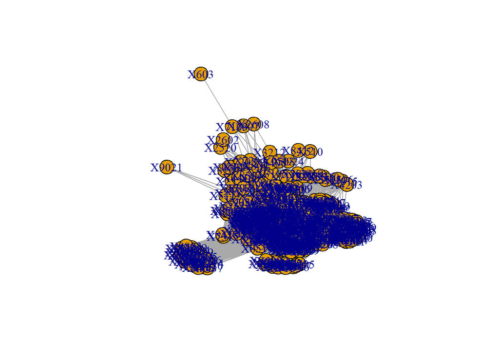

```r
plot(red_hidalgo1)
```

Árbol de expansión Máxima

Transforma la matriz en en NEGATIVA y para identificar los máximos

```r
M <- -M
head(M[,1:6])
```

```
##      X102 X210 X401 X403 X406 X510
## X102    0    0   -1   -1    0    0
## X210    0    0    0   -1   -1    0
## X401   -1    0    0    0    0    0
## X403   -1   -1    0    0   -1    0
## X406    0   -1    0   -1    0    0
## X510    0    0    0    0    0    0
```

Grafica de la nueva matriz negativa con MST con el input de la matriz en negativo que se acaba de generar.

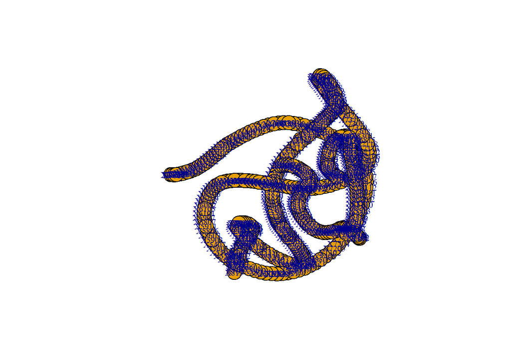

```r
red_hidalgo2 <- graph.adjacency(M, mode = "undirected" , weighted = TRUE)
MST <- minimum.spanning.tree(red_hidalgo2)
plot(MST, vertex.shapes="none", vertex.label.cex=.7)
```

Exportar red en formato gml. nodos n-1

```r
write.graph(MST,file = "redhidalgo2.gml", format = "gml")
```

Matriz de proximos adyaentes (nuevo relacionamiento)

```r
A <- get.adjacency(MST, sparse = F)
```

Exportar matriz de proximos adyacentes

```r
write.csv(A, file = "AdyacebtesConMST.csv")
```